# math250_nov5_lata

Author

Lata Bhatta

```r
library(tidyverse)
library(ISLR2)
library(palmerpenguins)

data("Carseats")
```

**Question 1:**

Does this data provide evidence against the company’s claim that the average price of their own seats is $110?

```r
glimpse(Carseats)
```

```
Rows: 400
Columns: 11
$ Sales       <dbl> 9.50, 11.22, 10.06, 7.40, 4.15, 10.81, 6.63, 11.85, 6.54, …
$ CompPrice   <dbl> 138, 111, 113, 117, 141, 124, 115, 136, 132, 132, 121, 117…
$ Income      <dbl> 73, 48, 35, 100, 64, 113, 105, 81, 110, 113, 78, 94, 35, 2…
$ Advertising <dbl> 11, 16, 10, 4, 3, 13, 0, 15, 0, 0, 9, 4, 2, 11, 11, 5, 0, …
$ Population  <dbl> 276, 260, 269, 466, 340, 501, 45, 425, 108, 131, 150, 503,…
$ Price       <dbl> 120, 83, 80, 97, 128, 72, 108, 120, 124, 124, 100, 94, 136…
$ ShelveLoc   <fct> Bad, Good, Medium, Medium, Bad, Bad, Medium, Good, Medium,…
$ Age         <dbl> 42, 65, 59, 55, 38, 78, 71, 67, 76, 76, 26, 50, 62, 53, 52…
$ Education   <dbl> 17, 10, 12, 14, 13, 16, 15, 10, 10, 17, 10, 13, 18, 18, 18…
$ Urban       <fct> Yes, Yes, Yes, Yes, Yes, No, Yes, Yes, No, No, No, Yes, Ye…
$ US          <fct> Yes, Yes, Yes, Yes, No, Yes, No, Yes, No, Yes, Yes, Yes, N…
```

```r
mean(Carseats$Price)
```

```
[1] 115.795
```

The sample mean is about $115.80, which is higher than the claimed $110.

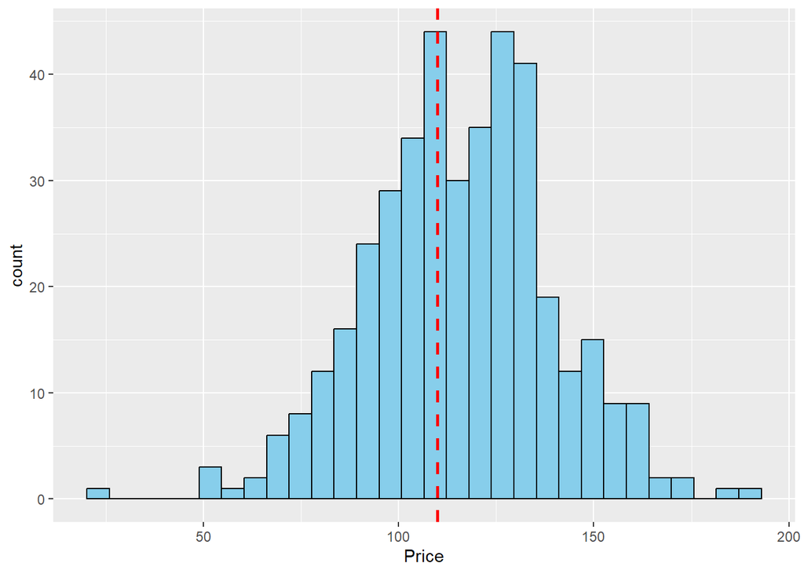

```r
ggplot(Carseats, aes(x = Price)) +
  geom_histogram(bins = 30,
                 fill = "skyblue",
                 color = "black") +
  geom_vline(xintercept = 110,
             color = "red",
             linetype = "dashed",
             linewidth = 1)
```

$H_0: \mu = 110$ (the population mean price is $110)

$H_a: \mu \ne 110$ (the population mean price is not $110)

```r
t.test(Carseats$Price, mu = 110)
```

```
    One Sample t-test

data:  Carseats$Price
t = 4.8951, df = 399, p-value = 1.429e-06
alternative hypothesis: true mean is not equal to 110
95 percent confidence interval:
 113.4677 118.1223
sample estimates:
mean of x
  115.795
```

**Conclusion** We reject the null hypothesis and conclude that the true average price is not $110. The actual average appears to be higher, around $115.80.

**Question 2:**

Compute a level 90% confidence interval for the mean competitor price in the population from which this sample is drawn. What is the sample mean? What is the margin of error?

```r
mean(Carseats$CompPrice)
```

```
[1] 124.975
```

```r
t.test(Carseats$CompPrice, conf.level = 0.90)
```

```
    One Sample t-test

data:  Carseats$CompPrice
t = 163, df = 399, p-value < 2.2e-16
alternative hypothesis: true mean is not equal to 0
90 percent confidence interval:
 123.7109 126.2391
sample estimates:
mean of x
  124.975
```

Sample mean: $124.97

90% Confidence Interval: ($123.71 , $126.23)

Margin of error: (126.23 - 123.71)/2 = $1.26

We are 90% confident that the true population mean competitor price falls between $123.71 and $126.23. The margin of error is about $1.26.

**Question 3:**

Create a table with counts of penguin species and home islands in the penguins set. Include marginal counts in your table.

```r
t<- table(penguins$species, penguins$island)
t
```

```
            Biscoe Dream Torgersen
  Adelie        44    56        52
  Chinstrap      0    68         0
  Gentoo       124     0         0
```

```r
addmargins(t)
```

```
            Biscoe Dream Torgersen Sum
  Adelie        44    56        52 152
  Chinstrap      0    68         0  68
  Gentoo       124     0         0 124
  Sum          168   124        52 344
```

**Question 4:**